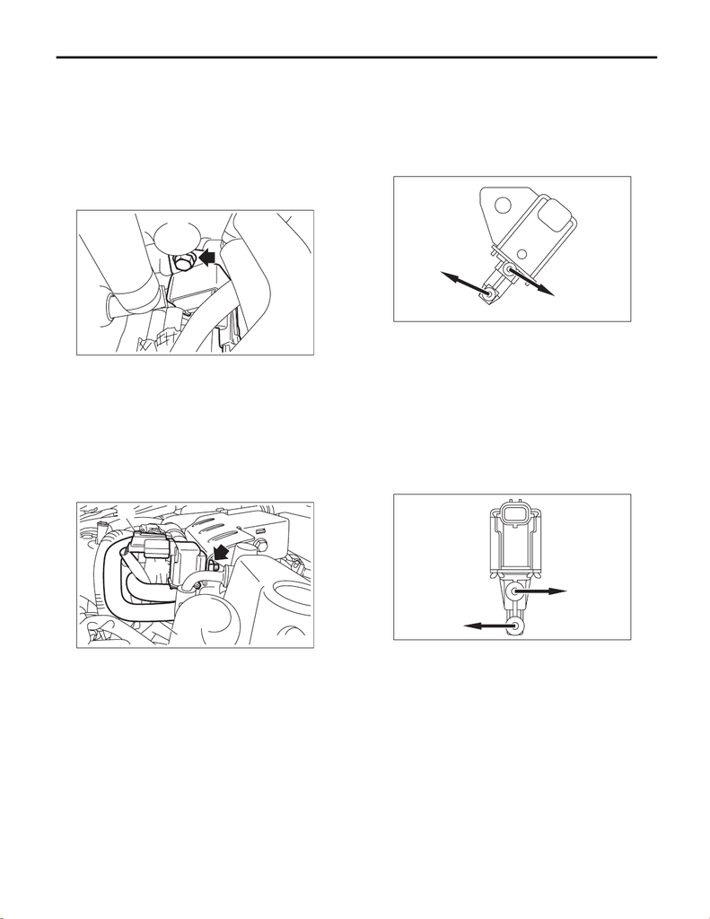

EC(STI)-22

Purge Control Solenoid Valve

EMISSION CONTROL (AUX. EMISSION CONTROL DEVICES)

5. Purge Control Solenoid Valve

A: REMOVAL

1. PURGE CONTROL SOLENOID VALVE 1

1) Disconnect the ground cable from battery.

2) Remove the bolts which secure purge control

solenoid valve 1 to the intake manifold, and discon-

nect the connector from the purge control solenoid

valve 1.

3) Disconnect the vacuum hose and the vacuum

control hose from purge control solenoid valve 1.

2. PURGE CONTROL SOLENOID VALVE 2

1) Disconnect the ground cable from battery.

2) Disconnect connector (A), vacuum hose (B), and

vacuum control hose (C) from purge control sole-

noid valve 2.

3) Remove purge control solenoid valve 2 from the

solenoid valve bracket.

B: INSTALLATION

1. PURGE CONTROL SOLENOID VALVE 1

Install in the reverse order of removal.

NOTE:

Connect the vacuum hose and vacuum control

hose as shown in the figure.

Tightening torque:

19 N·m (1.9 kgf-m, 14.0 ft-lb)

2. PURGE CONTROL SOLENOID VALVE 2

Install in the reverse order of removal.

NOTE:

Connect the vacuum hose and vacuum control

hose as shown in the figure.

Tightening torque:

6.4 N·m (0.7 kgf-m, 4.7 ft-lb)

EC-03446

EC-03447

(A)

(B)

(C)

(a) To intake manifold

(b) To branching pipe → fuel pipe

(a) To intake duct

(b) To branching pipe → fuel pipe

EC-02485

(b)

(a)

EC-02486

(a)

(b)

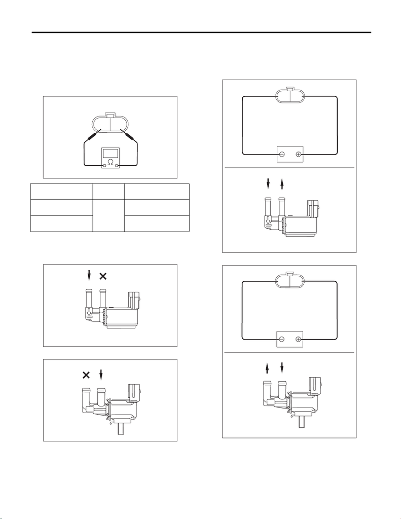

EC(STI)-23

Purge Control Solenoid Valve

EMISSION CONTROL (AUX. EMISSION CONTROL DEVICES)

C: INSPECTION

1. PURGE CONTROL SOLENOID VALVE

1) Check that the purge control solenoid valve has

no deformation, cracks or other damages.

2) Measure the resistance between the purge con-

trol solenoid valve terminals.

3) Check that air does not come out from (B) when

air is blown into (A).

• Purge control solenoid valve 1

• Purge control solenoid valve 2

4) Connect the battery positive terminal to the ter-

minal No. 1 and the battery negative terminal to the

terminal No. 2. Check that air is discharged from

(B), when supplying air to (A).

• Purge control solenoid valve 1

• Purge control solenoid valve 2

2. OTHER INSPECTIONS

Make sure the vacuum hoses and vacuum control

hoses are not cracked or loose.

Te r m i n a l

No.

Standard

Purge control sole-

noid valve 1

1 and 2

32±2 Ω

(when 20°C (68°F))

Purge control sole-

noid valve 2

24±3 Ω

(when 20°C (68°F))

21

EC-02426

EC-02474

(A)

(B)

EC-02431

(A)

(B)

21

(A)

(B)

EC-02475

EC-02432

21

(A)

(B)